# ggplot2_solutions_chapter8

Nade Kang

July 11, 2018

# Solution Manual for ggplot2 Elegant Graphics for Data Analysis by Hadley Wickham

# ggplot2 Chpater 8 Themes

## *Exercise 8.2.1*

### Load Packages

```r
library(tidyverse)
library(ggthemes)
```

*Question 1* Try out all the themes in ggthemes. Which do you like the best?

```r
df <- data.frame(x = c(1:4), y = c(5,8))
df
```

```
##   x y
## 1 1 5
## 2 2 8
## 3 3 5
## 4 4 8
```

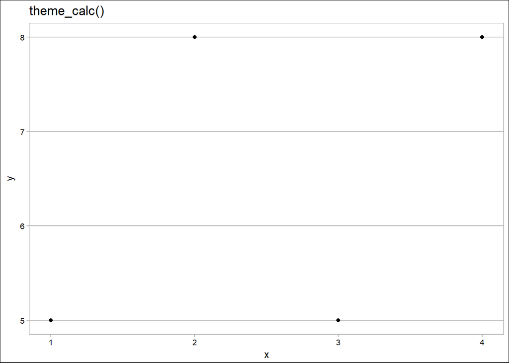

```r
ggplot(df, aes(x, y)) +
  geom_point() +
  theme_calc() +ggtitle("theme_calc()")
```

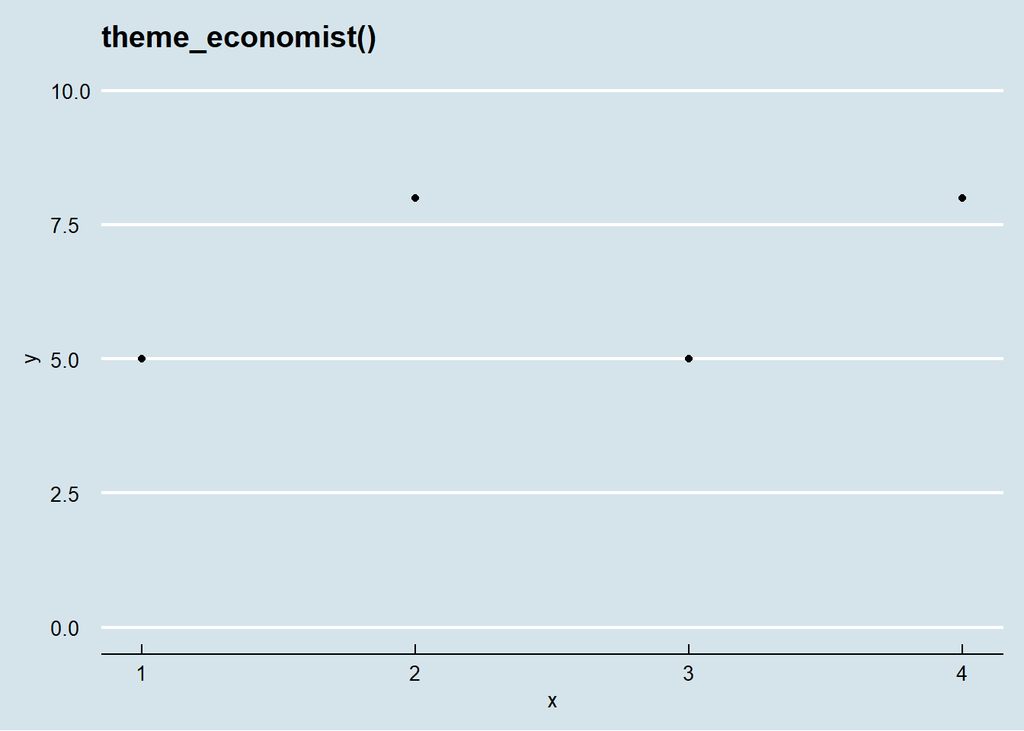

```r
ggplot(df, aes(x, y)) +
  geom_point() +
  theme_economist() +ggtitle("theme_economist()") +
  ylim(0, 10)
```

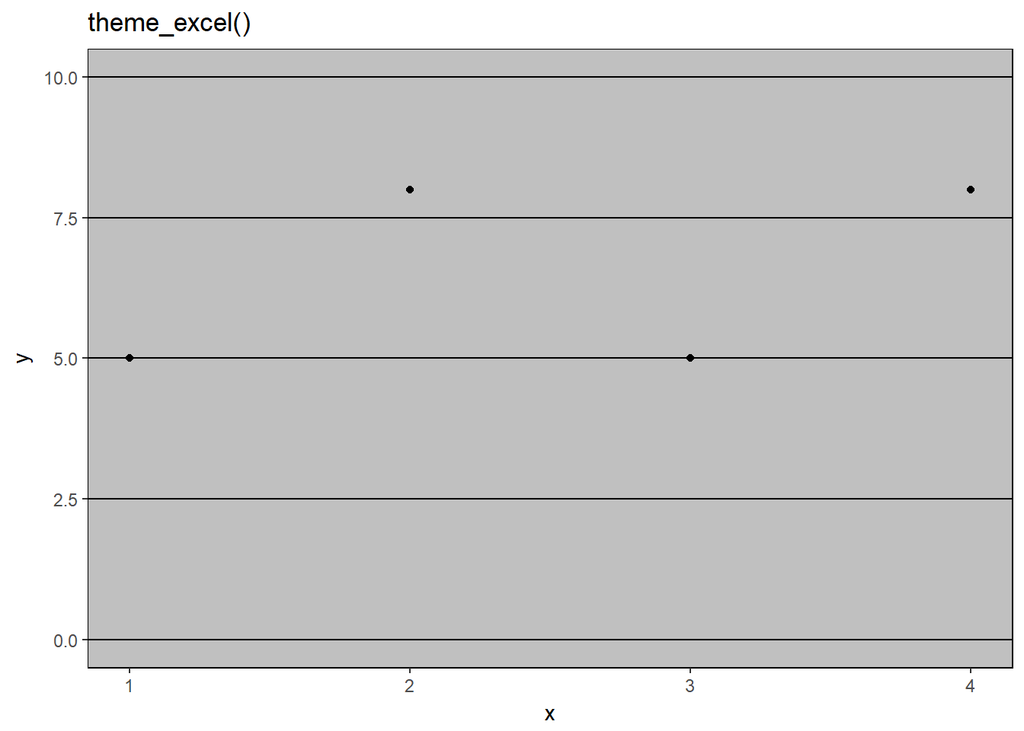

```r
ggplot(df, aes(x, y)) +
  geom_point() +
  theme_excel() +ggtitle("theme_excel()") +
  ylim(0, 10)
```

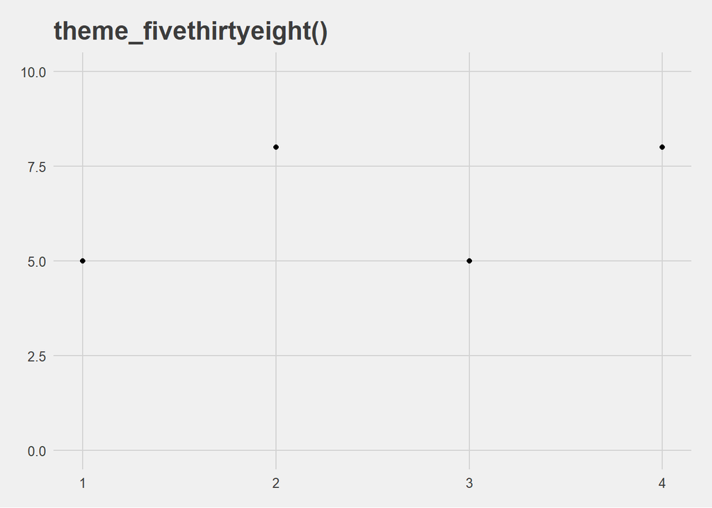

```r
ggplot(df, aes(x, y)) +
  geom_point() +
  theme_fivethirtyeight() +ggtitle("theme_fivethirtyeight()") +
  ylim(0, 10)
```

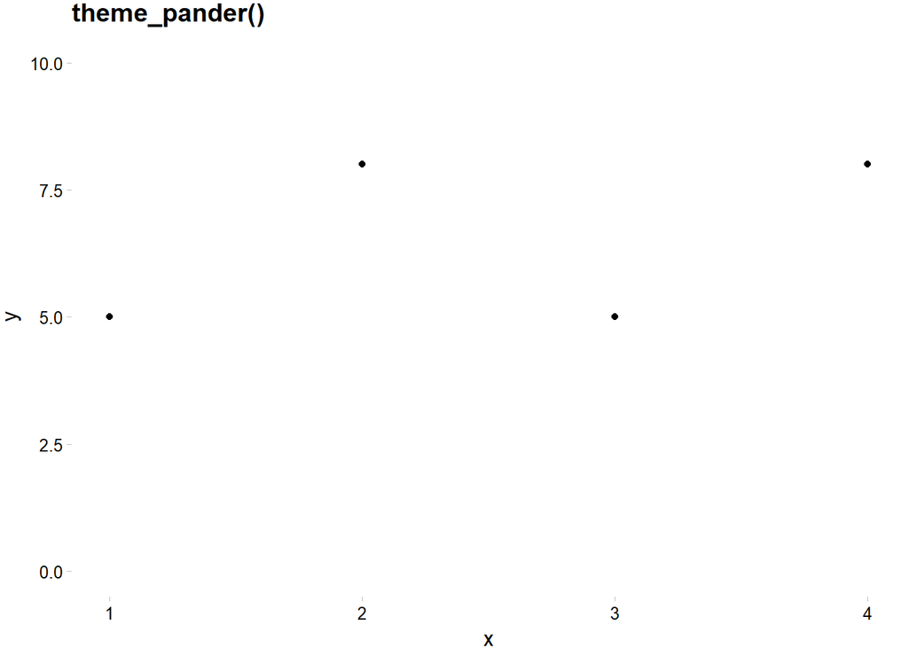

```r
ggplot(df, aes(x, y)) +
  geom_point() +
  theme_pander() +ggtitle("theme_pander()") +
  ylim(0, 10)
```

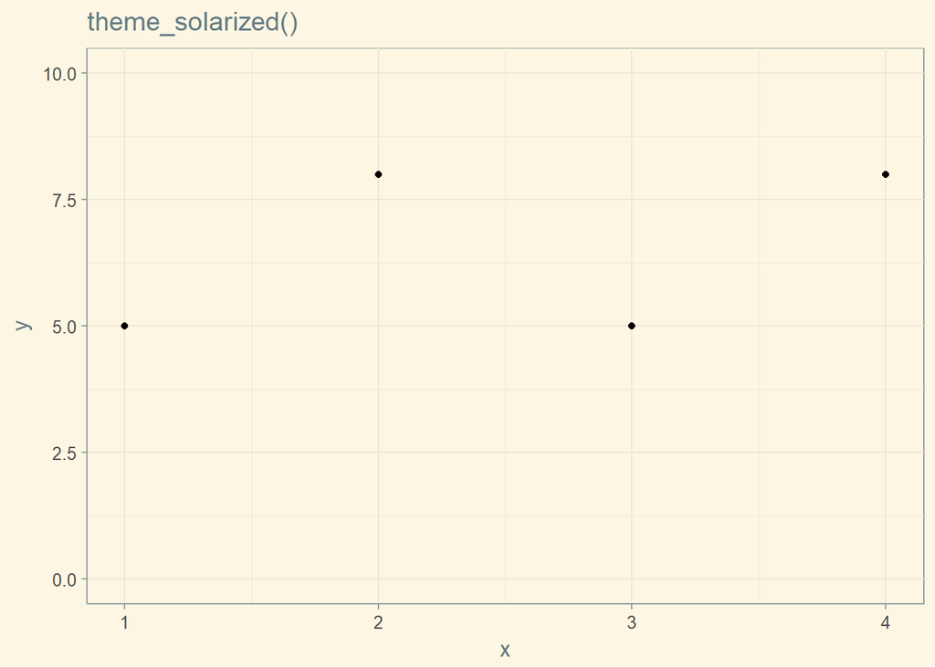

```r
ggplot(df, aes(x, y)) +
  geom_point() +
  theme_solarized() +ggtitle("theme_solarized()") +
  ylim(0, 10)
```

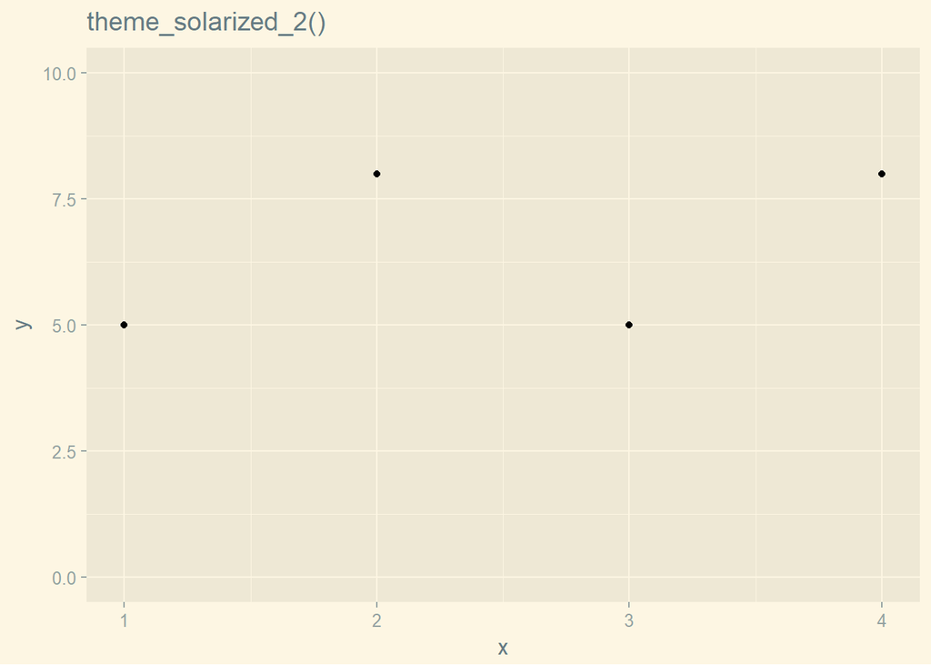

```r
ggplot(df, aes(x, y)) +
  geom_point() +
  theme_solarized_2() +ggtitle("theme_solarized_2()") +
  ylim(0, 10)
```

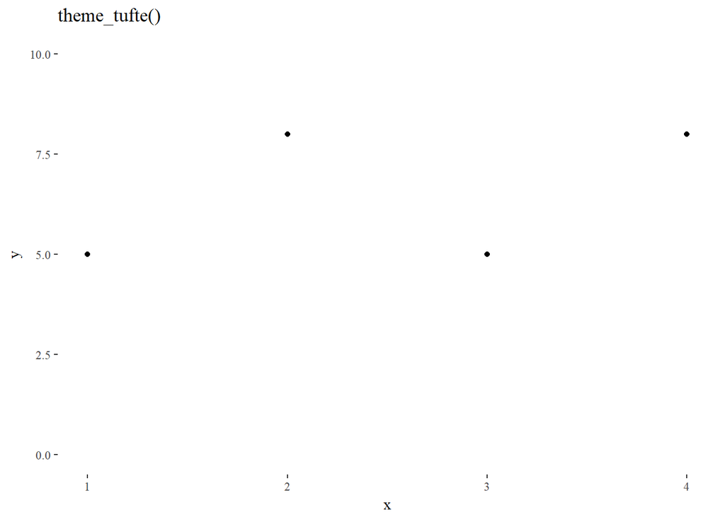

```r
ggplot(df, aes(x, y)) +
  geom_point() +
  theme_tufte() +ggtitle("theme_tufte()") +
  ylim(0, 10)
```

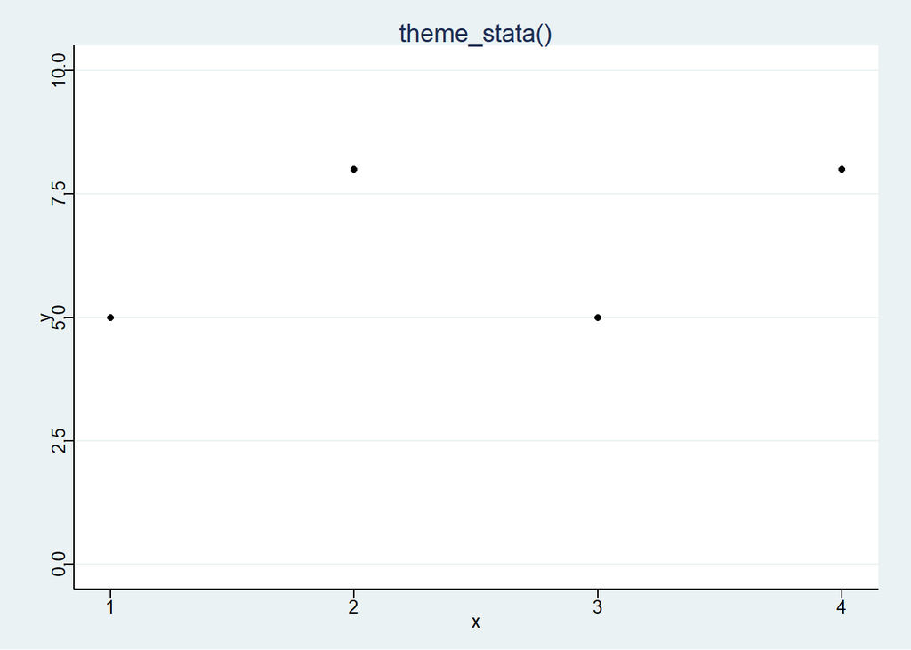

```r
ggplot(df, aes(x, y)) +
  geom_point() +
  theme_stata() +ggtitle("theme_stata()") +
  ylim(0, 10)
```

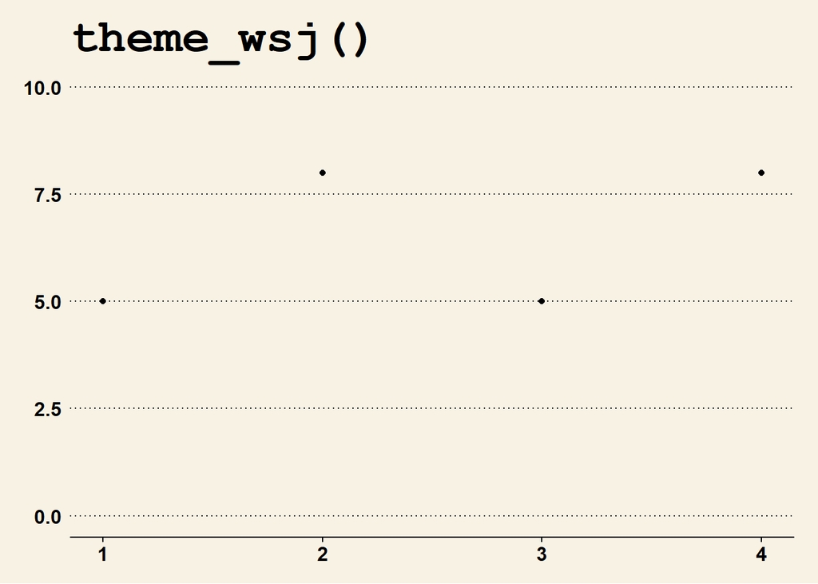

```r
ggplot(df, aes(x, y)) +
  geom_point() +
  theme_wsj() +ggtitle("theme_wsj()") +
  ylim(0, 10)
```

I like theme_solarized(), solarized_2, wsj, stata, and tufte.

*Question 2* What aspects of the default theme do you like? What don’t you like? What would you change?

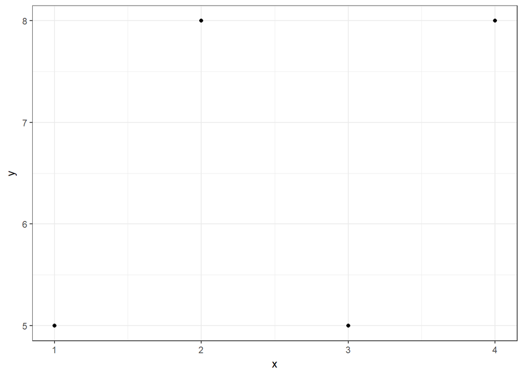

```r
ggplot(df, aes(x,y)) +
  geom_point() +
  theme_bw()
```

It’s quite a personal preference related question. I’ll try change in when plotting data.

*Question 3* Look at the plots in your favourite scientific journal. What theme do they most resemble? What are the main differences?

Not quite sure, probably some themes in stata could be more common? Some journals in finance uses theme_bw() quite often.

## *Exercises 8.4.6*

*Question 1* Create the ugliest plot possible! (Contributed by Andrew D. Steen, University of Tennessee - Knoxville)

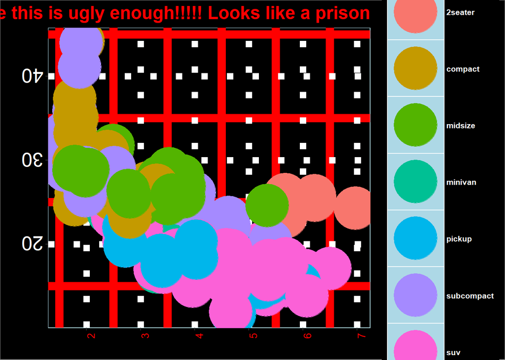

```r
ggplot(mpg, aes(displ, hwy)) +
  geom_point(position = "jitter", aes(color = class), size = 20) +
  ggtitle("Hope this is ugly enough!!!!! Looks like a prison") +
  labs(x = "Displacement eGINE", y = "highWAY miles Per miles", color = "type of CAR") +
  theme(legend.background = element_rect(fill = "black"),
        legend.key = element_rect("lightblue"),
        legend.text = element_text(color = "white", face = "bold", size = 8),
        legend.title = element_text(color = "white", face = "bold", size = 4),
        plot.title = element_text(hjust = 1, size = 18, face = "bold", color = "red"),
        plot.background = element_rect(fill = "black", color = "grey50"),
        panel.background = element_rect(fill = "black", color = "lightblue"),
        panel.grid.major = element_line(colour = "white", size = 3, linetype = "dotted"),
        panel.grid.minor = element_line(color = "red", size = 4),
        axis.text.x = element_text(angle = 90, vjust = 1, size = 10, color = "red"),
        axis.text.y = element_text(angle = 180, hjust = 2, size = 20, color = "white")
        )
```

*Question 2* theme dark() makes the inside of the plot dark, but not the outside. Change the plot background to black, and then update the text settings so you can still read the labels.

The best way to do so is to make the axis texts and axis titles color white.

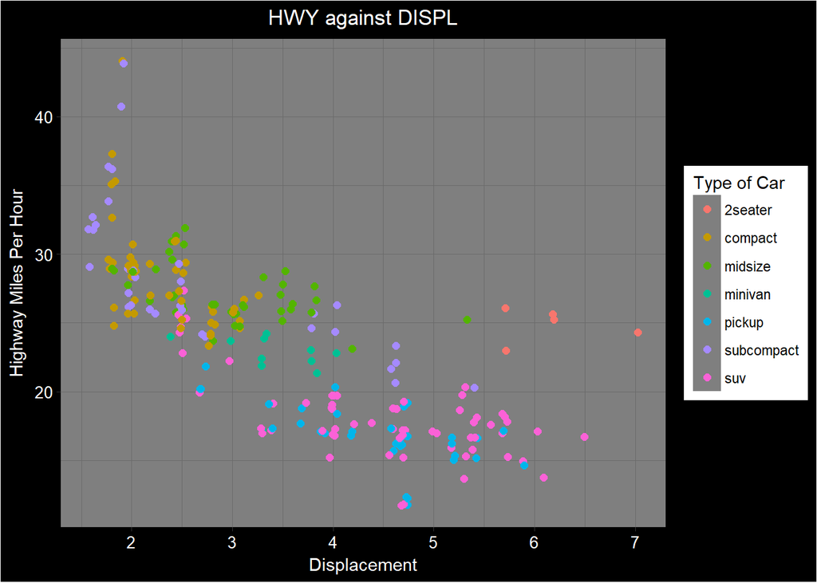

```r
ggplot(mpg, aes(displ, hwy)) +
  geom_point(position = "jitter", aes(color = class), size = 2) +
  theme_dark() +
  ggtitle("HWY against DISPL") +
  theme(plot.background = element_rect(fill = "black")) +
  labs(x = "Displacement", y = "Highway Miles Per Hour", color = "Type of Car") +
  theme(axis.text.x = element_text(size = 10, color = "white"),
        axis.text.y = element_text(size = 10, color = "white"),
        axis.title = element_text(color = "white"),
        plot.title = element_text(color = "white", hjust = 0.5))
```

*Question 3* Make an elegant theme that uses “linen” as the background colour and a serif font for the text.

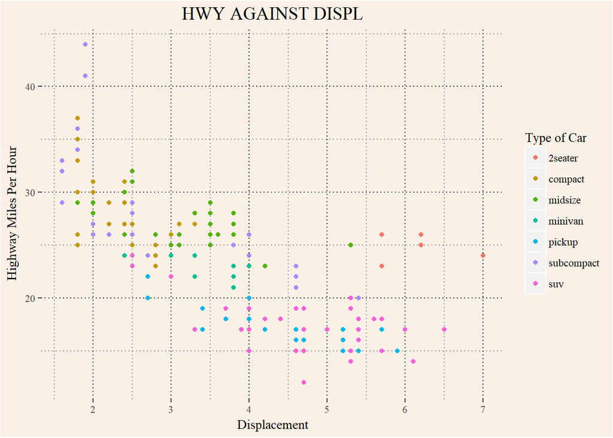

```r
ggplot(mpg, aes(displ, hwy)) +
  geom_point(aes(color = class)) +
  ggtitle("HWY AGAINST DISPL") +
  labs(x = "Displacement", y = "Highway Miles Per Hour", color = "Type of Car") +
  theme(plot.background = element_rect(fill = "linen"),
        panel.background = element_rect(fill = "linen"),
        plot.title = element_text(hjust = 0.5, size = 15, family = "serif"),
        text = element_text(family = "serif"),
        legend.background = element_rect(fill = "linen"),
        legend.text = element_text(family = "serif"),
        panel.grid.major = element_line(linetype = "dotted", color = "black", size = 0.4),
        panel.grid.minor = element_line(linetype = "dotted", color = "grey50", size = 0.4))
```

*Question 4* Systematically explore the effects of hjust when you have a multiline title. Why doesn’t vjust do anything?

When you have a long title, it will show up as the following: the title is not completely shown in the output plot.

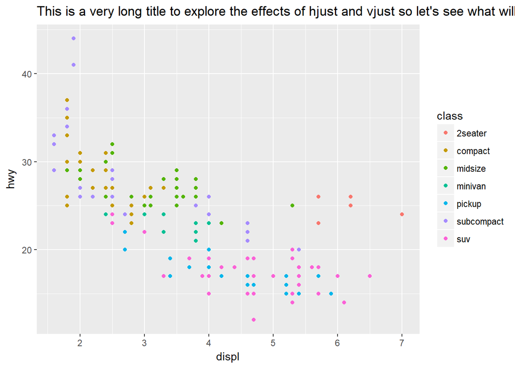

```r
ggplot(mpg, aes(displ, hwy)) +
  geom_point(aes(color = class)) +
  ggtitle("This is a very long title to explore the effects of hjust and vjust so let's see what will happen to the plot and answer the question")
```

Let’s try use different levels of vjust:

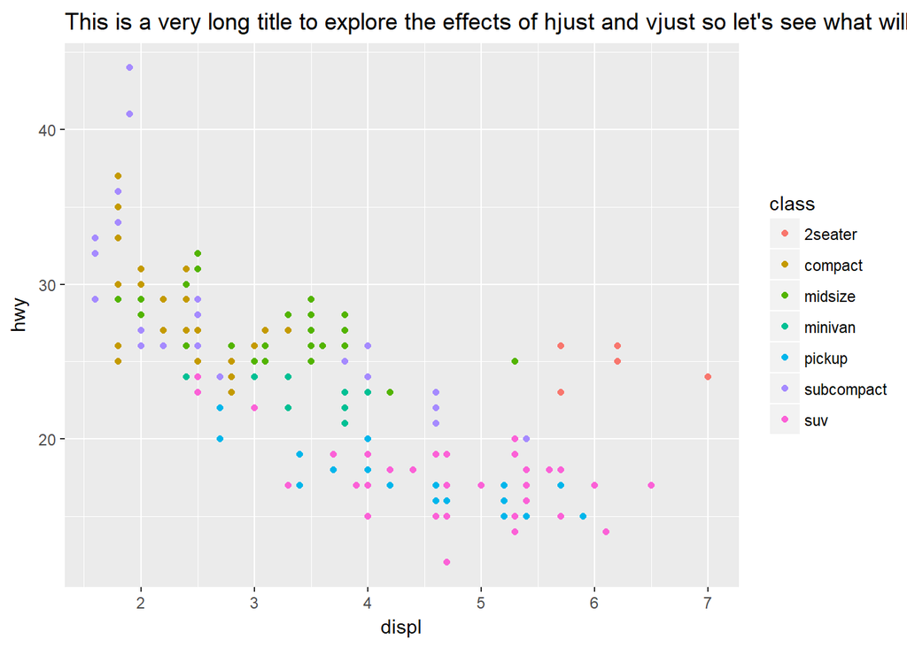

```r
ggplot(mpg, aes(displ, hwy)) +
  geom_point(aes(color = class)) +
  ggtitle("This is a very long title to explore the effects of hjust and vjust so let's see what will happen to the plot and answer the question") +
  theme(plot.title = element_text(vjust = 0.5))
```

It seems that no matter vjust is 0, 0.5 or even you put 1, it doesn’t help with the issue.

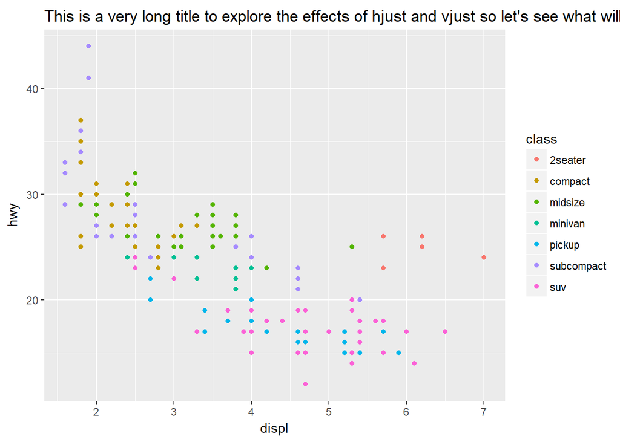

```r
ggplot(mpg, aes(displ, hwy)) +
  geom_point(aes(color = class)) +
  ggtitle("This is a very long title to explore the effects of hjust and vjust so let's see what will happen to the plot and answer the question") +
  theme(plot.title = element_text(vjust = 0))
```

The reason is that, vjust means vertical adjustment. When the full title is not shown, adjusting the vertical position doesn’t help with the problem. Instead, we can use hjust combined with expression(atop()) nested functions.

The expression(atop()) functions allow you to separate the title into different pieces of strings, separated by comma. Thus adding hjust = 0.5 will put the title in to multiple lines and centered in the middle.

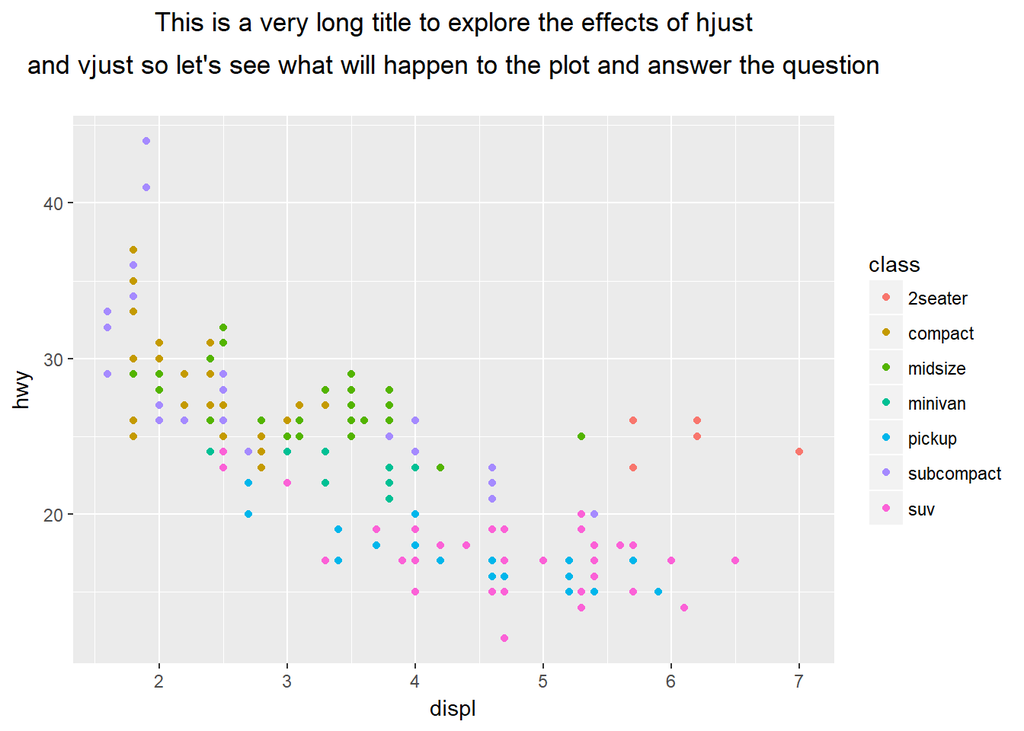

```r
ggplot(mpg, aes(displ, hwy)) +
  geom_point(aes(color = class)) +
  ggtitle(expression(atop("This is a very long title to explore the effects of hjust", "and vjust so let's see what will happen to the plot and answer the question"))) +
  theme(plot.title = element_text(hjust = 0.5))
```